# 2012 Data RMD V3

Scott Stoner

2023

## Data Import

This section covers importing lake chemistry and watershed data for the purpose of lake selection. The relevant data is first retrieved from one of the NLS 2012 csv files. These variables fall into three categories, watershed information, water chemistry data, and diatom phytoplankton counts. Additional variables are included to help with ID or shed light on connections made during anlaysis. Variable names and notes are included for each imported data set.

#### Site Info

- AREA_HA (lake area, hectares)
- STATE
- SIZE_CLASS
- SITETYPE (probability or handpicked)
- ELEVATION
- FS_EW (forest service land east or west)
- DSGN12 (incorporated in the NLA2012 design framework)
- NA_L2CODE (ecoregion level 2)
- NA_L3CODE (ecoregion level 3)
- URBAN (determination based on land use)
- EVAL_NAME (lake name)
- LAKE_ORIGIN (“manmade or natural”)
- PERIM_KM (lake perimeter)
- SITESAMP (was site sampled)
- DATE_COL (date of sample collection)
- SITE_ID (id code for site 2012 version)
- VISIT_NO (visit number for site)
- UID (unique site visit id)

```r
tb_import(c("UID", "SITE_ID", "VISIT_NO", "DATE_COL", "SITETYPE", "SITESAMP", "DSGN12", "EVAL_NAME","STATE", "ELEVATION", "AREA_HA", "PERIM_KM","SIZE_CLASS", "FS_EW","NA_L2CODE", "NA_L3CODE","URBAN", "LAKE_ORIGIN"), "./data/nla2012_wide_siteinfo_08232016.csv") -> siteinfo
```

#### Watershed Data

- SITE_ID
- DOMGEOL_BSN (dominant geology)
- HOUSEDEN_BSN (housing density in basin housing units/sq mi)
- NLCD2006_ASSIGNEDAREA_BSN (area within basin assigned nlcd value*)
- NLCD2006_DEVELOPEDPCT_BSN (percent developed)
- NLCD2006_FORESTPCT_BSN (percent forest)
- NLCD2006_IMPERVPCT_BSN (percent impervious)
- NLCD2006_12PCT_BSN (percent perennial ice)
- NLCD2006_AGRICPCT_BSN (percent cultivated/planted)
- NLCD2006_WETLANDPCT_BSN (percent wetland)
- POPDEN_BSN (people/sq mi)
- PMEAN_BSN (mean annual precipitation in basin)[multiple precip values]
- TMEANPY_BSN (mean temperature in basin 12 months)[multiple temp values]

```r
tb_import(c("SITE_ID", "DOMGEOL_BSN", "HOUSEDEN_BSN", "NLCD2006_ASSIGNEDAREA_BSN", "NLCD2006_DEVELOPEDPCT_BSN", "NLCD2006_FORESTPCT_BSN", "NLCD2006_IMPERVPCT_BSN", "NLCD2006_12PCT_BSN", "NLCD2006_AGRICPCT_BSN", "NLCD2006_WETLANDPCT_BSN", "POPDEN_BSN", "PMEAN_BSN", "TMEANPY_BSN"), "./data/nla2012_wide_watershed.csv") -> watershed
```

#### Water Chemistry Data

- UID
- NTL_RESULT (Total Nitrogen mg/L)
- PTL_RESULT (Total Phosphorus ug/L)
- PH_RESULT (Standard logarithmic pH scale)
- TURB_RESULT (Turbidity, Unspecified Units, non-logarithmic)
- COND_RESULT (Conductivity, uS/cm @ 25 C)
- CHLORIDE_RESULT (Chloride mg/L)
- NITRATE_N_RESULT (Nitrate mg N/L)
- NITRITE_N_RESULT (Nitrite mg N/L)
- SULFATE_RESULT (Sulfate mg/L)
- CALCIUM_RESULT (Calcium mg/L)
- AMMONIA_N_RESULT (Ammonia mg N/L)
- DOC_RESULT (Dissolved Organic Carbon mg/L)
- SODIUM_RESULT (Sodium mg/L)
- MAGNESIUM_RESULT (Magnesium mg/L)
- POTASSIUM_RESULT (Potassium mg/L)

```r
waterchem_cols <- c("UID", "NTL_RESULT", "PTL_RESULT", "PH_RESULT", "TURB_RESULT", "COND_RESULT", "CHLORIDE_RESULT", "NITRATE_N_RESULT", "NITRITE_N_RESULT", "SULFATE_RESULT", "CALCIUM_RESULT", "AMMONIA_N_RESULT", "DOC_RESULT", "SODIUM_RESULT", "MAGNESIUM_RESULT", "POTASSIUM_RESULT")
tb_import(waterchem_cols, "./data/nla2012_waterchem_wide.csv") -> waterchem
```

#### Phytoplankton Data

- UID
- SAMPLE_ID
- VISIT_NO
- ABUNDANCE
- ALGAL_GROUP
- TAXA_ID

```r
tb_import(c("UID", "SAMPLE_ID", "VISIT_NO", "ABUNDANCE", "ALGAL_GROUP", "TAXA_ID"), "./data/nla2012_wide_phytoplankton_count_02122014.csv") %>%
  dplyr::filter(ALGAL_GROUP == "DIATOM") %>%
  dplyr::filter(VISIT_NO == 1) -> phyto_count
```

## Lake Selection

#### Data Merge and Initial Filter

The selected watershed and water chemistry data from the imported tables is now combined into a single table that will be used for lake selection. A left join using the SITE_ID field to append watershed data to general site info. Then a left join is used to append the water chemistry data to each visit using the UID field. This table is then filtered to remove undesired lakes. First, lakes with no sampling data are excluded, followed by lakes that were not randomly selected, and third by visit number, removing duplicate visits.

#### Lake Selection

In the same code chunk below is where the bulk of the lake selection process happens.

List of selection conditions in order:

1. NA_L2CODE = 6.2
- The 6.2 NA Ecoregion 2 Code represents the “Western Cordillera” also known as the Northwestern Forested Mountain Region.
2. STATE = CA, OR, WA, ID, MT
- The restriction to these 5 states removes areas of Ecoregion 6.2 that are mostly in Colorado and New Mexico.
3. Possible to use more criteria here to narrow selection.

```r
siteinfo %>%
  dplyr::left_join(watershed, by = "SITE_ID") %>%
  dplyr::left_join(waterchem, by = "UID") %>%
  dplyr::filter(SITESAMP == "Y") %>%
  dplyr::filter(SITETYPE == "PROB") %>%
  dplyr::filter(VISIT_NO == 1) %>%
  dplyr::filter(NA_L2CODE == 6.2) %>%
  dplyr::filter(STATE == "CA" | STATE == "OR" | STATE == "WA" | STATE == "ID" | STATE == "MT") -> watershed_filter_result
```

#### Phytoplankton Data Selection

```r
watershed_filter_result %>%
  dplyr::select("UID", "NTL_RESULT", "PTL_RESULT", "PH_RESULT", "TURB_RESULT", "COND_RESULT", "CHLORIDE_RESULT", "NITRATE_N_RESULT", "NITRITE_N_RESULT", "SULFATE_RESULT", "CALCIUM_RESULT", "AMMONIA_N_RESULT", "DOC_RESULT", "SODIUM_RESULT", "MAGNESIUM_RESULT", "POTASSIUM_RESULT") -> watershed_filter_IDs

phyto_count %>%
  dplyr::inner_join(watershed_filter_IDs, by = "UID",suffix = c(".x", ".y")) -> phyto_filtered

phyto_filtered %>%
  dplyr::select("UID", "TAXA_ID", "ABUNDANCE") %>%
  dplyr::group_by(TAXA_ID) %>%
  pivot_wider(names_from = TAXA_ID, values_from = ABUNDANCE, values_fn = sum, names_glue = "TID_{TAXA_ID}") %>%
  dplyr::inner_join(watershed_filter_result, by = "UID") %>%
  dplyr::mutate(lake = as.character(1:80))  -> phyto_metadata

phyto_metadata %>%
  dplyr::select(-one_of("UID", "NTL_RESULT", "PTL_RESULT", "PH_RESULT", "TURB_RESULT", "COND_RESULT", "CHLORIDE_RESULT", "NITRATE_N_RESULT", "NITRITE_N_RESULT", "SULFATE_RESULT", "CALCIUM_RESULT", "AMMONIA_N_RESULT", "DOC_RESULT", "SODIUM_RESULT", "MAGNESIUM_RESULT", "POTASSIUM_RESULT", "VISIT_NO", "SITE_ID", "DOMGEOL_BSN", "HOUSEDEN_BSN", "NLCD2006_ASSIGNEDAREA_BSN", "NLCD2006_DEVELOPEDPCT_BSN", "NLCD2006_FORESTPCT_BSN", "NLCD2006_IMPERVPCT_BSN", "NLCD2006_12PCT_BSN", "NLCD2006_AGRICPCT_BSN", "NLCD2006_WETLANDPCT_BSN", "POPDEN_BSN", "PMEAN_BSN", "TMEANPY_BSN", "VISIT_NO", "DATE_COL", "SITETYPE", "SITESAMP", "DSGN12", "EVAL_NAME","STATE", "ELEVATION", "AREA_HA", "PERIM_KM","SIZE_CLASS", "FS_EW","NA_L2CODE", "NA_L3CODE","URBAN", "LAKE_ORIGIN", "lake")) %>%
  sqrt() %>%
  replace(is.na(.), 0) -> phyto_taxa
```

## Data Summary

```r
set.seed(710)
watershed_filter_result %>%
  dplyr::select(all_of(waterchem_cols)) %>%
  dplyr::select(-one_of("UID", "COND_RESULT", "PH_RESULT")) %>%
  replace(is.na(.), 0) %>%
  dplyr::mutate(PTL_RESULT = PTL_RESULT/1000) %>%
  +1 %>%
  log() %>%
  replace(is.na(.), 0) %>%
  prcomp() -> waterchem_pca

summary(waterchem_pca)
```

```
## Importance of components:
##                           PC1    PC2     PC3     PC4     PC5     PC6     PC7
## Standard deviation     1.7195 0.8134 0.67712 0.52699 0.47473 0.36662 0.32169
## Proportion of Variance 0.6054 0.1355 0.09387 0.05686 0.04614 0.02752 0.02119
## Cumulative Proportion  0.6054 0.7408 0.83471 0.89157 0.93772 0.96524 0.98642
##                            PC8     PC9    PC10    PC11     PC12      PC13
## Standard deviation     0.23230 0.10680 0.02688 0.01400 0.005033 0.0002754
## Proportion of Variance 0.01105 0.00234 0.00015 0.00004 0.000010 0.0000000
## Cumulative Proportion  0.99747 0.99981 0.99995 0.99999 1.000000 1.0000000
```

```r
waterchem_pca$x %>%
  data.frame() %>%
  dplyr::select(1:2) -> waterchem_pc1_2

watershed_filter_result %>%
  mutate(PC1 = waterchem_pc1_2$PC1, PC2 = waterchem_pc1_2$PC2) -> waterchem_pca_metadata

waterchem_pca$rotation %>%
  data.frame() %>%
  dplyr::select(1:2)
```

```
##                            PC1           PC2
## NTL_RESULT       -7.463632e-02  0.1162796413
## PTL_RESULT       -8.676375e-03 -0.0049831034
## TURB_RESULT      -5.570331e-02  0.0190002685
## CHLORIDE_RESULT  -3.637398e-01  0.4997644476
## NITRATE_N_RESULT -1.105471e-04  0.0007071308
## NITRITE_N_RESULT -1.875658e-06  0.0000310862
## SULFATE_RESULT   -4.557528e-01 -0.0096705396
## CALCIUM_RESULT   -4.304204e-01 -0.6651676930
## AMMONIA_N_RESULT -3.229921e-03  0.0030308431
## DOC_RESULT       -2.186328e-01  0.3229627766
## SODIUM_RESULT    -3.470549e-01 -0.0485698168
## MAGNESIUM_RESULT -4.593548e-01 -0.1589174842
## POTASSIUM_RESULT -2.944617e-01  0.4023166480
```

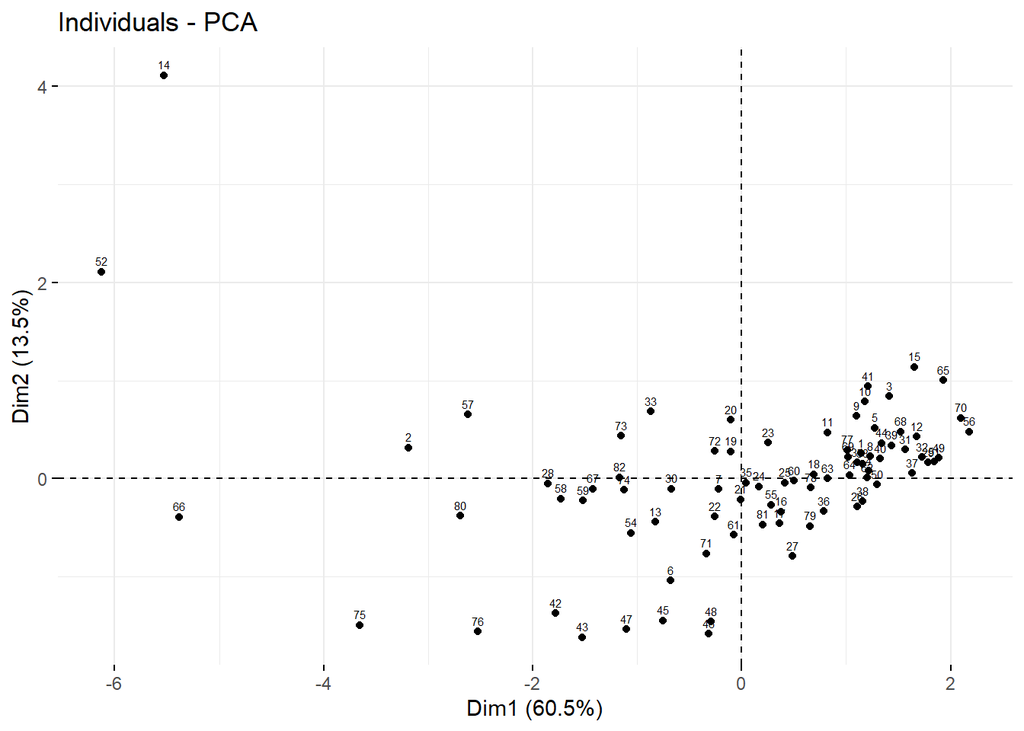

```r
fviz_pca_ind(waterchem_pca, labels = 2)
```

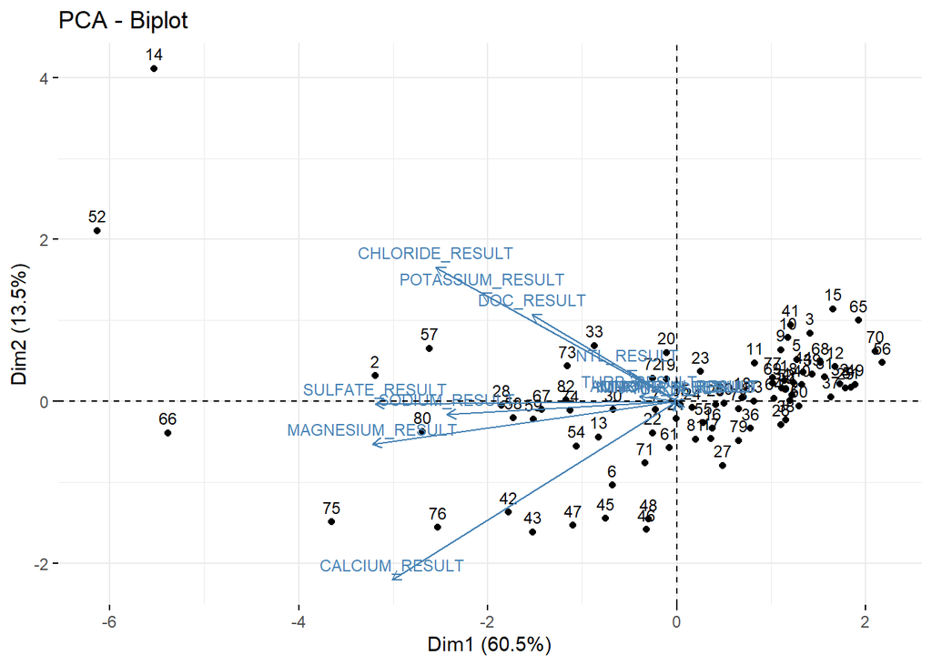

```r
fviz_pca_biplot(waterchem_pca, labelsize = 3)
```

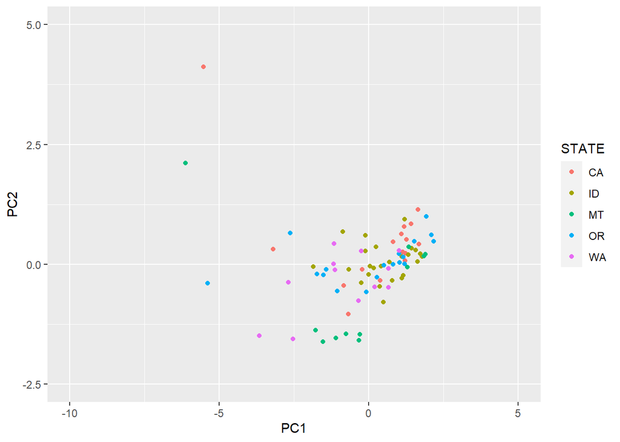

```r
waterchem_pca_metadata %>% ggplot(aes(x = PC1, y = PC2, color = STATE)) + geom_point() + ylim(-2.5,5) + xlim(-10,5)
```

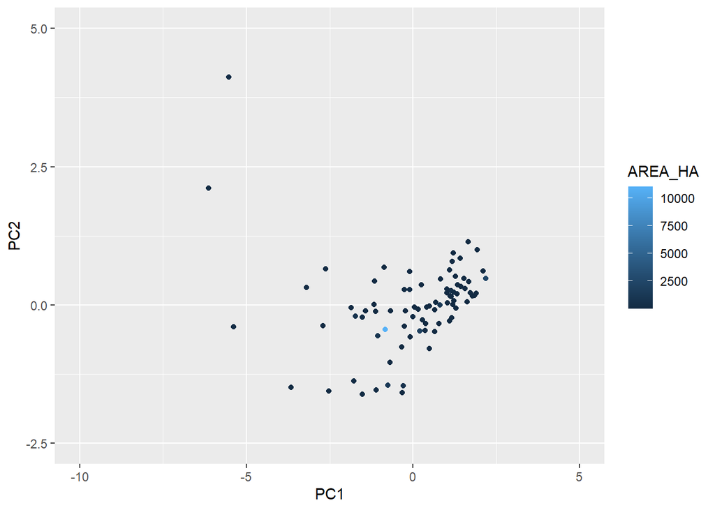

```r
waterchem_pca_metadata %>% ggplot(aes(x = PC1, y = PC2, color = AREA_HA)) + geom_point() + ylim(-2.5,5) + xlim(-10,5)
```

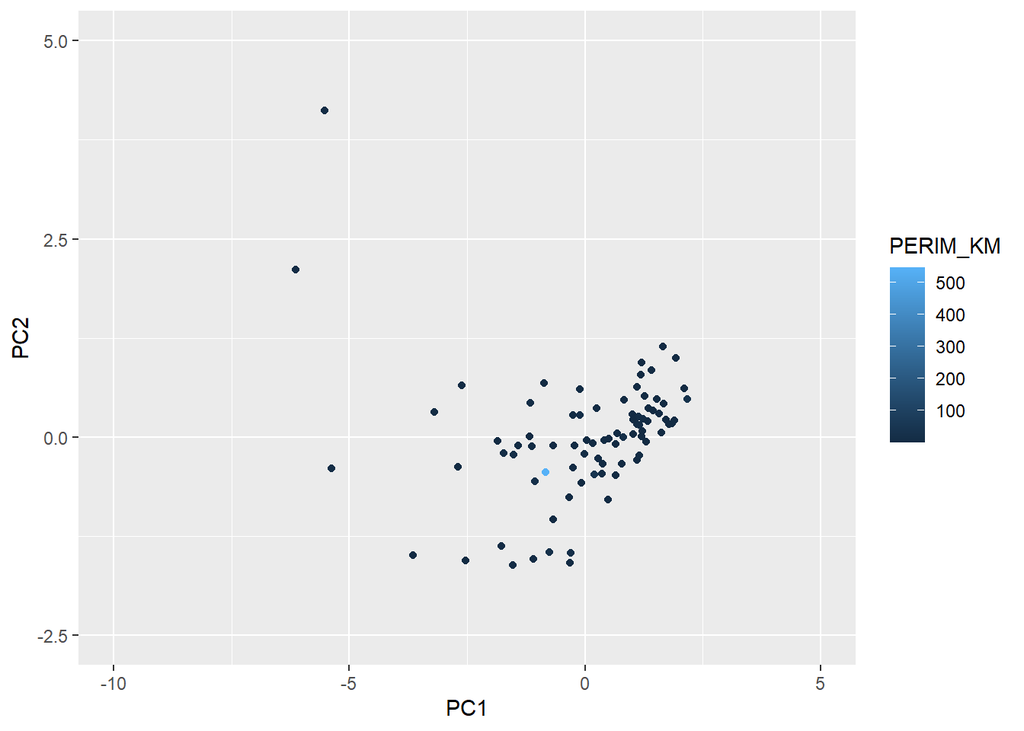

```r
waterchem_pca_metadata %>% ggplot(aes(x = PC1, y = PC2, color = PERIM_KM)) + geom_point() + ylim(-2.5,5) + xlim(-10,5)
```

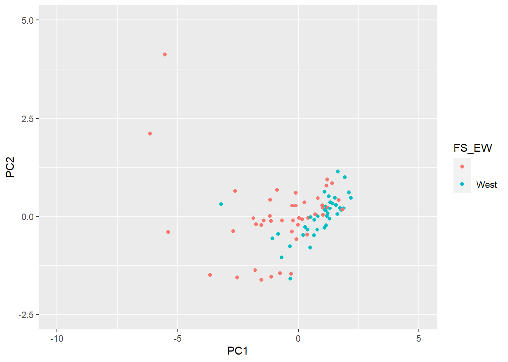

```r
waterchem_pca_metadata %>% ggplot(aes(x = PC1, y = PC2, color = FS_EW)) + geom_point() + ylim(-2.5,5) + xlim(-10,5)
```

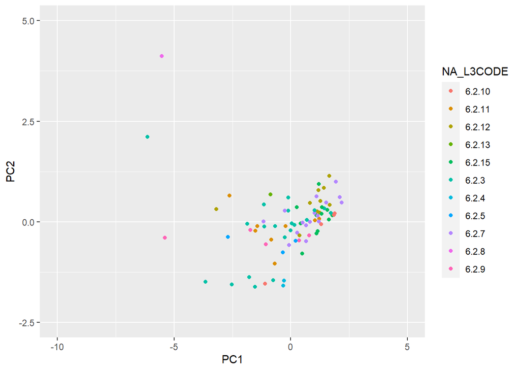

```r
waterchem_pca_metadata %>% ggplot(aes(x = PC1, y = PC2, color = NA_L3CODE)) + geom_point() + ylim(-2.5,5) + xlim(-10,5)
```

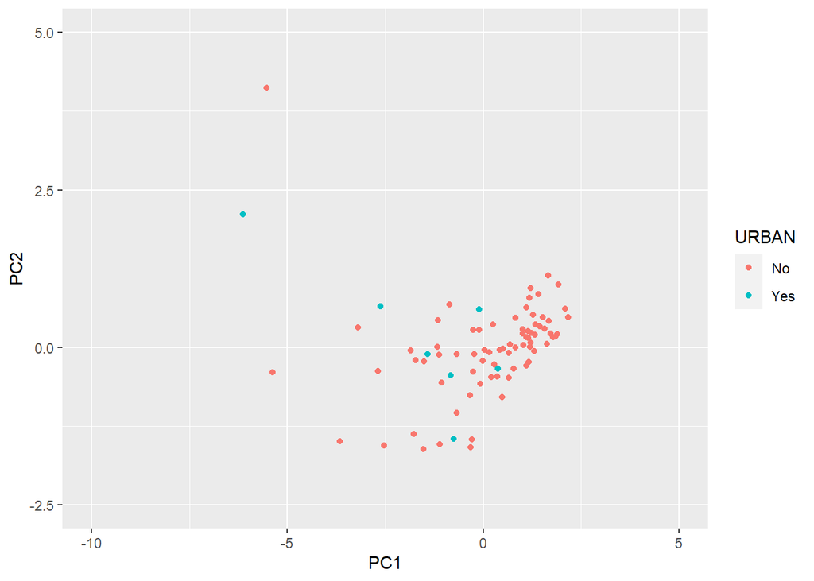

```r
waterchem_pca_metadata %>% ggplot(aes(x = PC1, y = PC2, color = URBAN)) + geom_point() + ylim(-2.5,5) + xlim(-10,5)
```

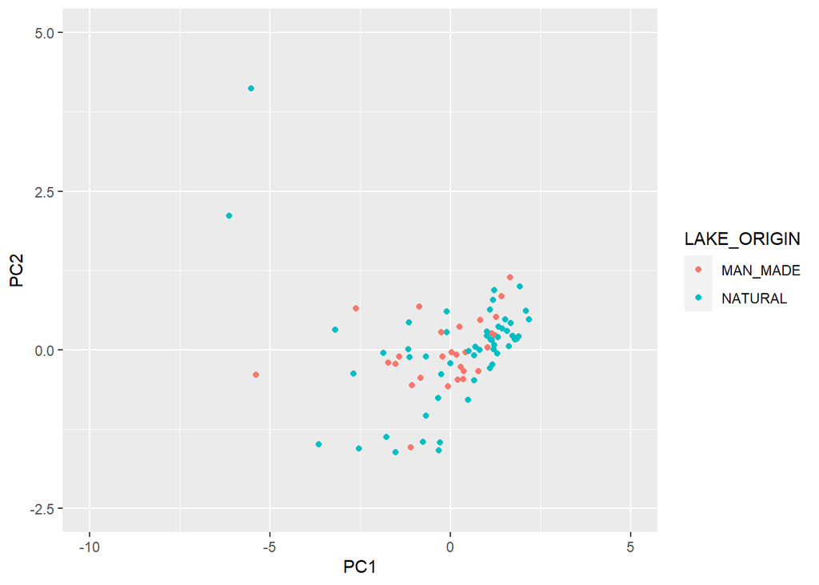

```r
waterchem_pca_metadata %>% ggplot(aes(x = PC1, y = PC2, color = LAKE_ORIGIN)) + geom_point() + ylim(-2.5,5) + xlim(-10,5)
```

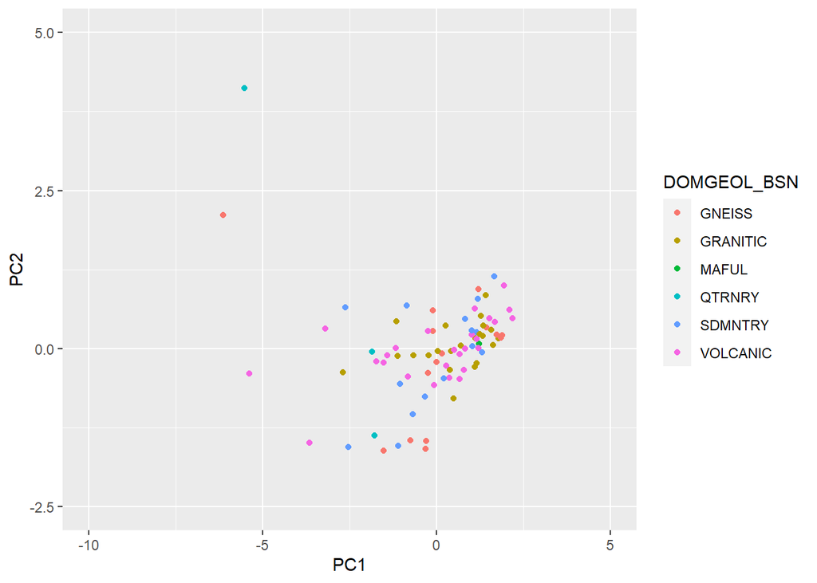

```r
waterchem_pca_metadata %>% ggplot(aes(x = PC1, y = PC2, color = DOMGEOL_BSN)) + geom_point() + ylim(-2.5,5) + xlim(-10,5)
```

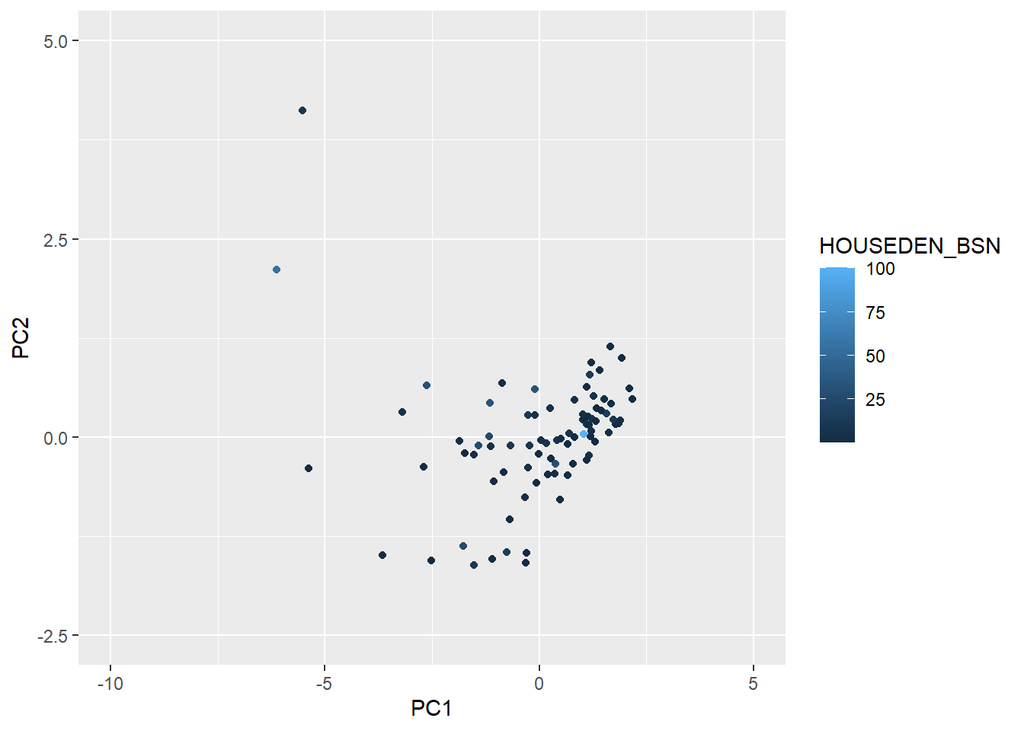

```r
waterchem_pca_metadata %>% ggplot(aes(x = PC1, y = PC2, color = HOUSEDEN_BSN)) + geom_point() + ylim(-2.5,5) + xlim(-10,5)
```

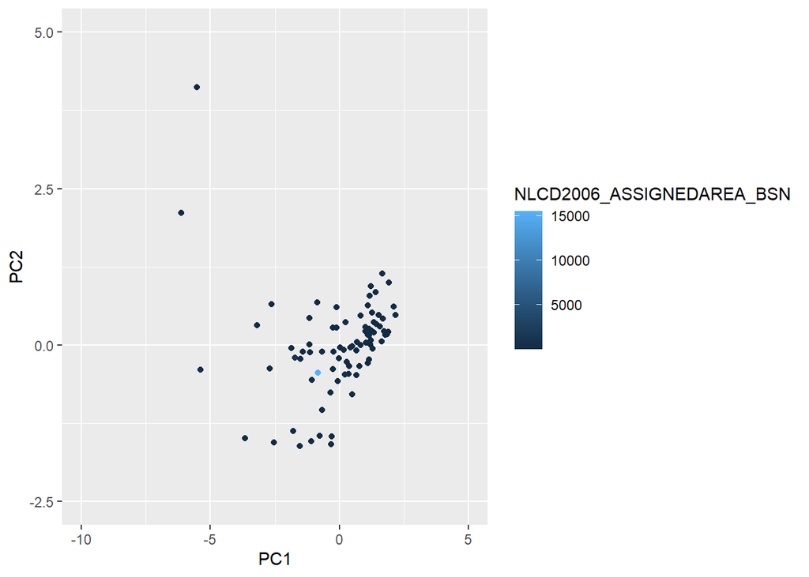

```r
waterchem_pca_metadata %>% ggplot(aes(x = PC1, y = PC2, color = NLCD2006_ASSIGNEDAREA_BSN)) + geom_point() + ylim(-2.5,5) + xlim(-10,5)
```

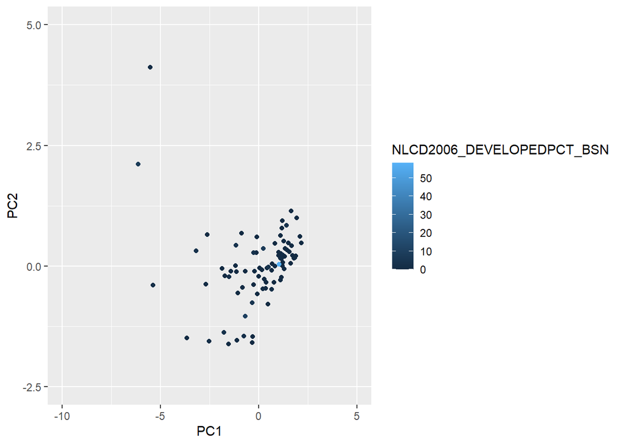

```r
waterchem_pca_metadata %>% ggplot(aes(x = PC1, y = PC2, color = NLCD2006_DEVELOPEDPCT_BSN)) + geom_point() + ylim(-2.5,5) + xlim(-10,5)
```

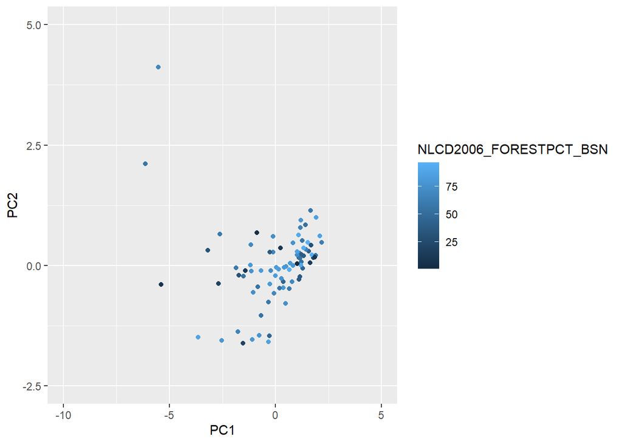

```r
waterchem_pca_metadata %>% ggplot(aes(x = PC1, y = PC2, color = NLCD2006_FORESTPCT_BSN)) + geom_point() + ylim(-2.5,5) + xlim(-10,5)
```

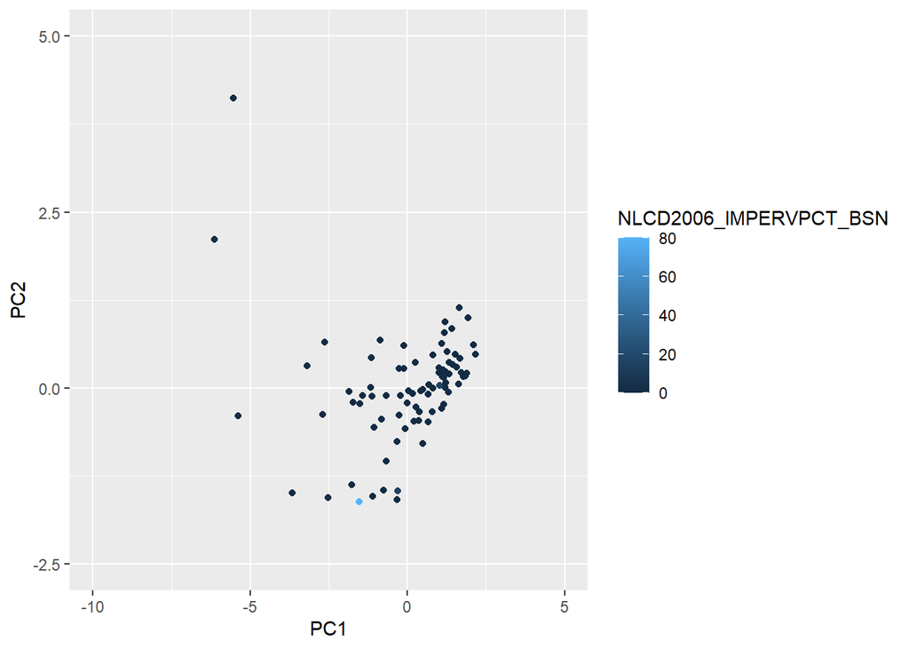

```r
waterchem_pca_metadata %>% ggplot(aes(x = PC1, y = PC2, color = NLCD2006_IMPERVPCT_BSN)) + geom_point() + ylim(-2.5,5) + xlim(-10,5)
```

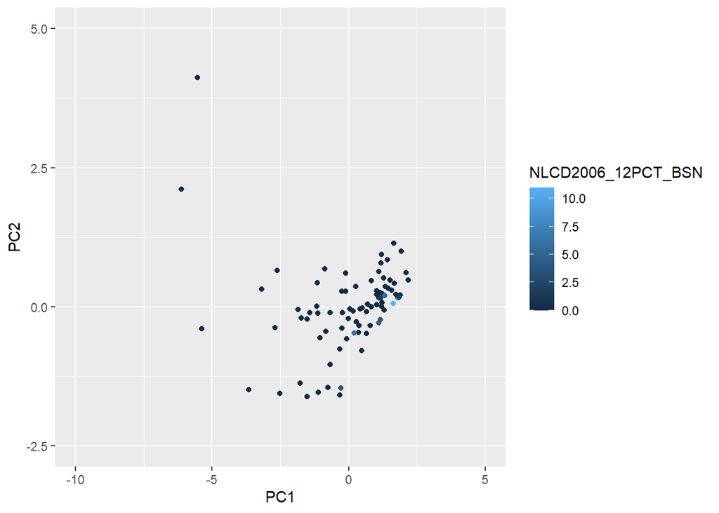

```r
waterchem_pca_metadata %>% ggplot(aes(x = PC1, y = PC2, color = NLCD2006_12PCT_BSN)) + geom_point() + ylim(-2.5,5) + xlim(-10,5)
```

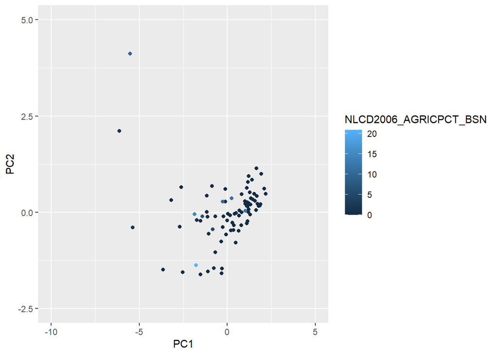

```r
waterchem_pca_metadata %>% ggplot(aes(x = PC1, y = PC2, color = NLCD2006_AGRICPCT_BSN)) + geom_point() + ylim(-2.5,5) + xlim(-10,5)
```

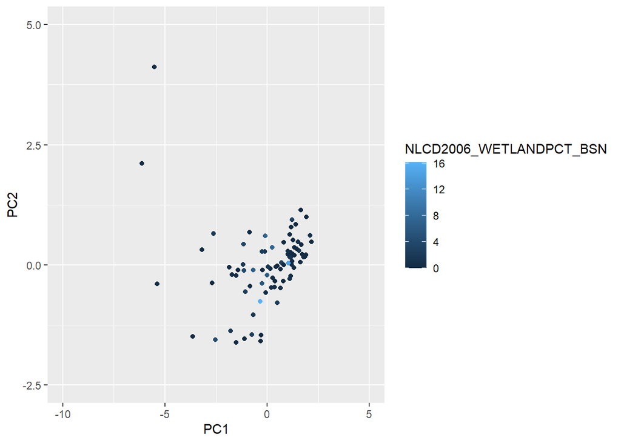

```r
waterchem_pca_metadata %>% ggplot(aes(x = PC1, y = PC2, color = NLCD2006_WETLANDPCT_BSN)) + geom_point() + ylim(-2.5,5) + xlim(-10,5)
```

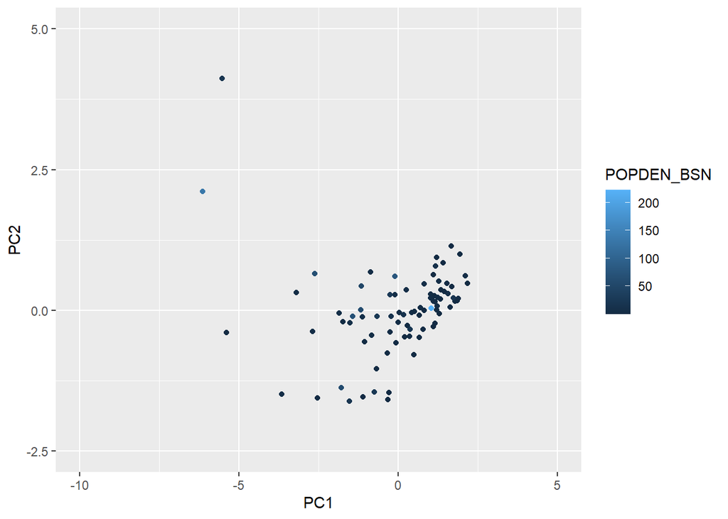

```r
waterchem_pca_metadata %>% ggplot(aes(x = PC1, y = PC2, color = POPDEN_BSN)) + geom_point() + ylim(-2.5,5) + xlim(-10,5)
```

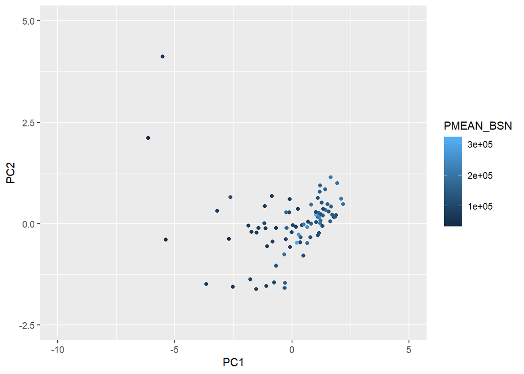

```r
waterchem_pca_metadata %>% ggplot(aes(x = PC1, y = PC2, color = PMEAN_BSN)) + geom_point() + ylim(-2.5,5) + xlim(-10,5)
```

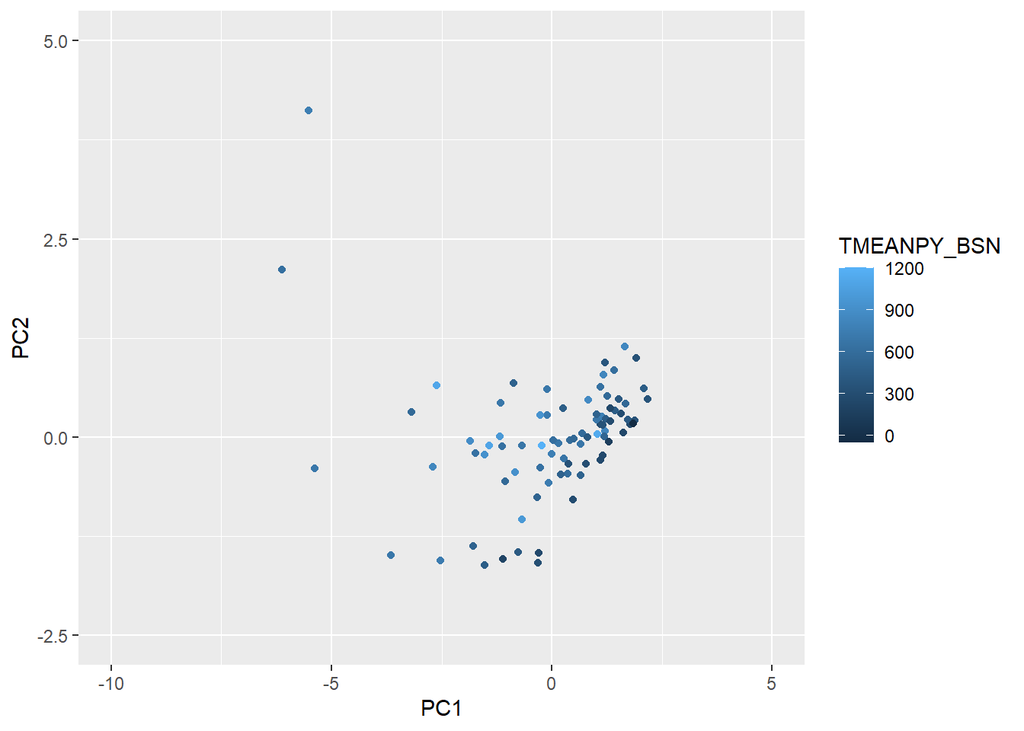

```r
waterchem_pca_metadata %>% ggplot(aes(x = PC1, y = PC2, color = TMEANPY_BSN)) + geom_point() + ylim(-2.5,5) + xlim(-10,5)
```

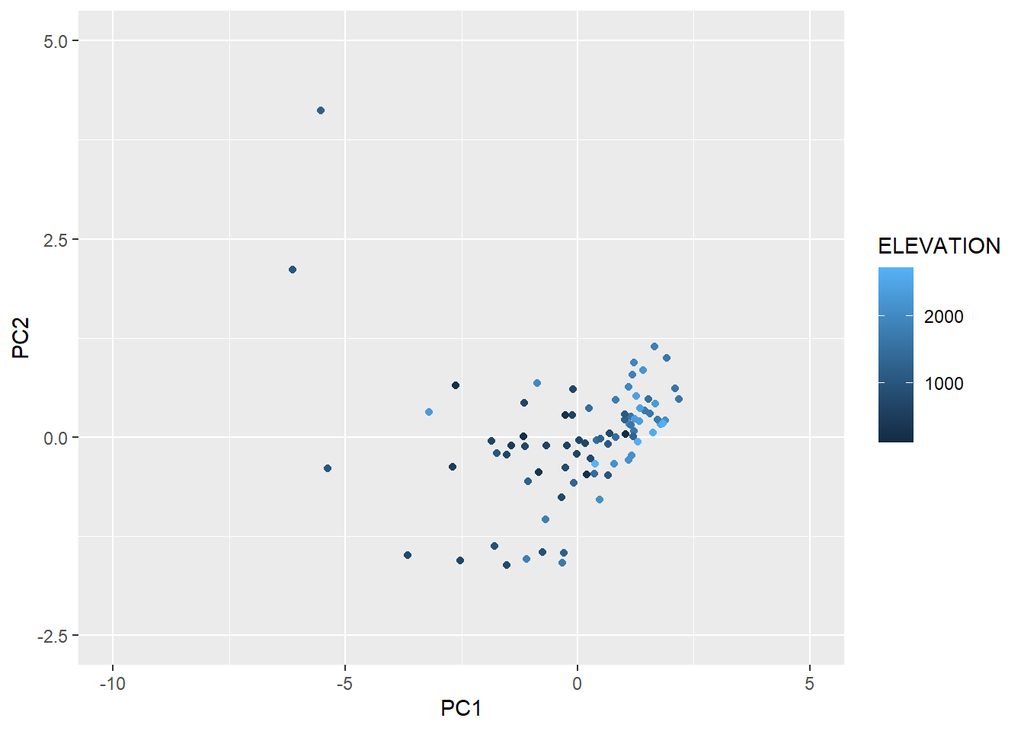

```r
waterchem_pca_metadata %>% ggplot(aes(x = PC1, y = PC2, color = ELEVATION)) + geom_point() + ylim(-2.5,5) + xlim(-10,5)
```

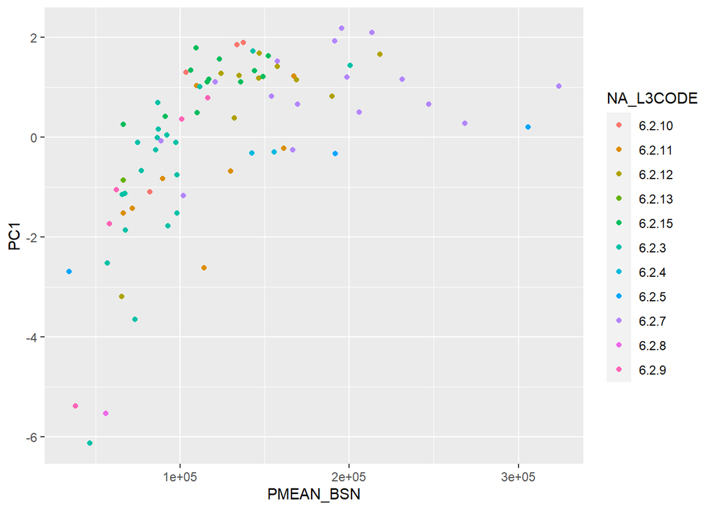

```r
waterchem_pca_metadata %>%
  ggplot(aes(x = PMEAN_BSN, y = PC1, color = NA_L3CODE)) + geom_point()
```

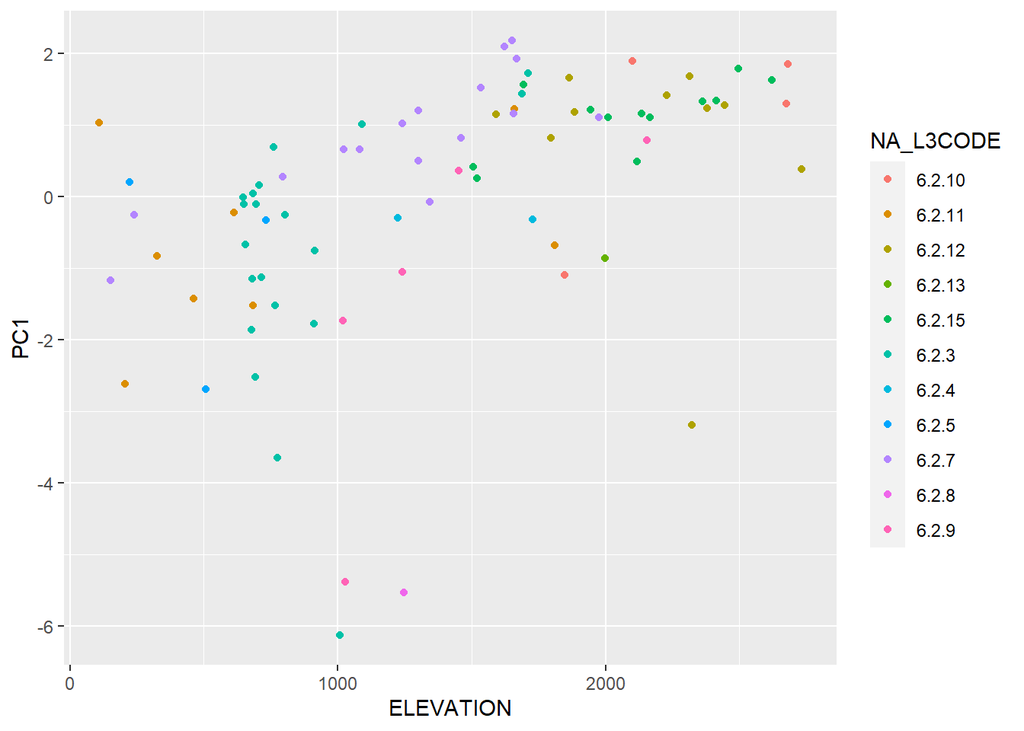

```r
waterchem_pca_metadata %>%
  ggplot(aes(x = ELEVATION, y = PC1, color = NA_L3CODE)) + geom_point()
```

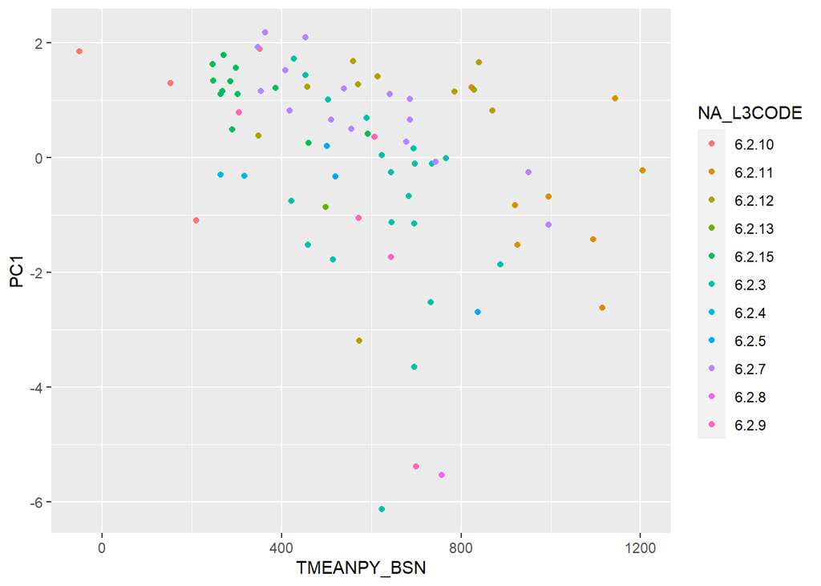

```r
waterchem_pca_metadata %>%
  ggplot(aes(x = TMEANPY_BSN, y = PC1, color = NA_L3CODE)) + geom_point()
```

## NMDS

```r
set.seed(710)
phyto_taxa %>%
metaMDS(k=2,trace=T,autotransform =F) -> phyto_nmds
```

```
## *** Best solution was not repeated -- monoMDS stopping criteria:
##      2: no. of iterations >= maxit
##     18: stress ratio > sratmax
```

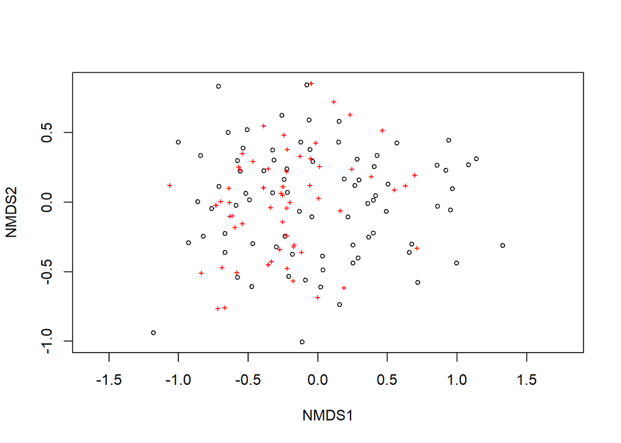

```r
plot(phyto_nmds)
```

```r
phyto_nmds$points %>%
  as_tibble(rownames="lake") %>%
  dplyr::inner_join(phyto_metadata, by = "lake") -> nmds_result

nmds_result %>%
  dplyr::select("NTL_RESULT", "PTL_RESULT", "PH_RESULT", "TURB_RESULT", "CHLORIDE_RESULT",
                "NITRATE_N_RESULT", "NITRITE_N_RESULT", "SULFATE_RESULT", "CALCIUM_RESULT",
                "AMMONIA_N_RESULT", "DOC_RESULT", "SODIUM_RESULT", "MAGNESIUM_RESULT", "POTASSIUM_RESULT") -> nmds_chem
```

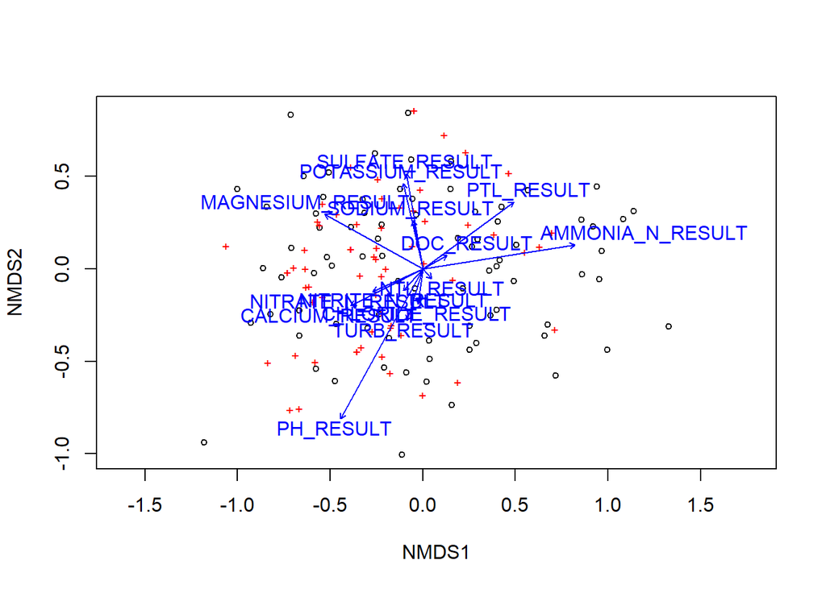

```r
envfit(ord = phyto_nmds, nmds_chem, perm = 999, na.rm = TRUE) -> nmds_ordination

plot(phyto_nmds)
plot(nmds_ordination)
```

```r
nmds_ordination$vectors$r
```

```
##       NTL_RESULT       PTL_RESULT        PH_RESULT      TURB_RESULT
##     0.0004507475     0.0336998731     0.0770303372     0.0077037927
##  CHLORIDE_RESULT NITRATE_N_RESULT NITRITE_N_RESULT   SULFATE_RESULT
##     0.0032984104     0.0079073726     0.0022287372     0.0245574817
##   CALCIUM_RESULT AMMONIA_N_RESULT       DOC_RESULT    SODIUM_RESULT
##     0.0173132979     0.0622779665     0.0020011873     0.0064018907
## MAGNESIUM_RESULT POTASSIUM_RESULT
##     0.0333232005     0.0201860174
```

```r
nmds_ordination$vectors$pvals
```

```
##       NTL_RESULT       PTL_RESULT        PH_RESULT      TURB_RESULT
##            0.987            0.328            0.082            0.796
##  CHLORIDE_RESULT NITRATE_N_RESULT NITRITE_N_RESULT   SULFATE_RESULT
##            0.918            0.786            0.931            0.451
##   CALCIUM_RESULT AMMONIA_N_RESULT       DOC_RESULT    SODIUM_RESULT
##            0.582            0.133            0.943            0.864
## MAGNESIUM_RESULT POTASSIUM_RESULT
##            0.407            0.575
```

```r
nmds_scores = as.data.frame(scores(phyto_nmds)$sites)
phyto_metadata$NMDS1 = nmds_scores$NMDS1
phyto_metadata$NMDS2 = nmds_scores$NMDS2
```

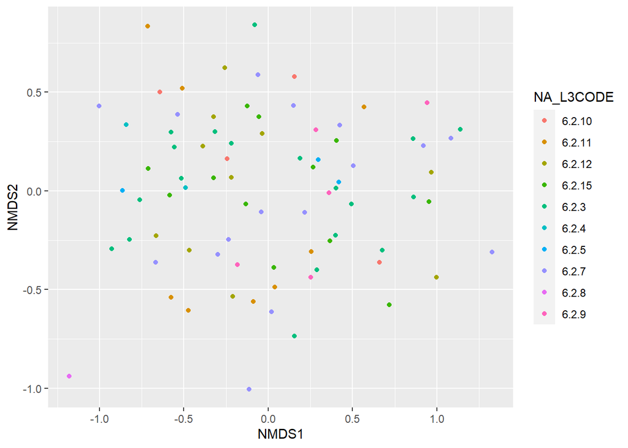

```r
phyto_metadata %>%
  ggplot(aes(x = NMDS1, y = NMDS2, color = NA_L3CODE)) + geom_point()
```